# White Wine Quality Analysis by Vijayasarathi

## Fixed Acidity and Volatile Acidity

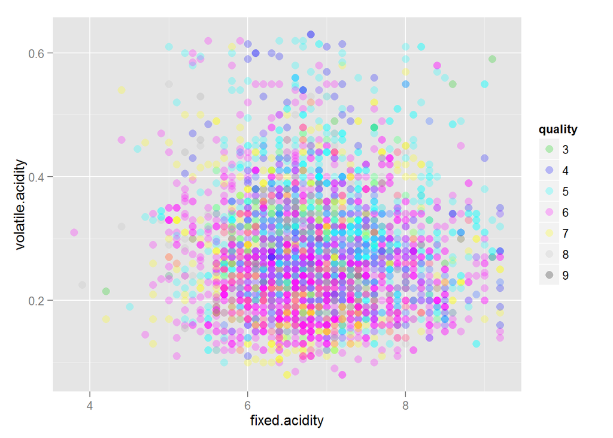

```r
ggplot(aes(x = fixed.acidity,
           y = volatile.acidity,
           color = quality),
       data = whitewine) +
       geom_point(size = 3, alpha = 1/4) +
    scale_color_identity(guide = 'legend') +
    ylim(min(whitewine$volatile.acidity),
         quantile(whitewine$volatile.acidity, 0.99)) +
    xlim(min(whitewine$fixed.acidity),
         quantile(whitewine$fixed.acidity, 0.99))
```

samples of quality ‘6’ are highly concentrated around volatile acidity of 0.2 and fixed acidity of 6-7.

Free Sulfur Dioxide and Total Sulfur Dioxide

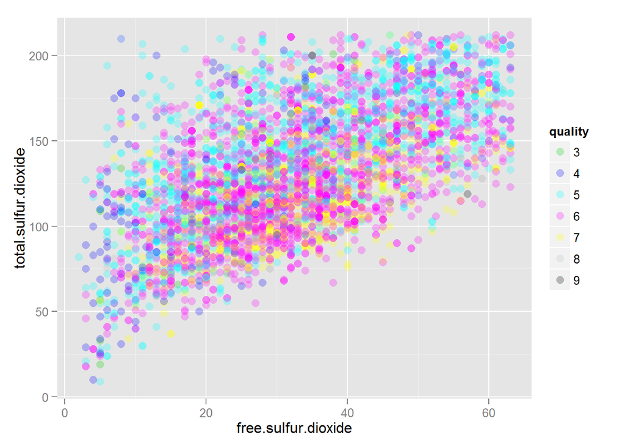

```r
ggplot(aes(x = free.sulfur.dioxide,
           y = total.sulfur.dioxide,
           color = quality),
       data = whitewine) +
       geom_point(size = 3, alpha = 1/4) +
    scale_color_identity(guide = 'legend') +
    ylim(min(whitewine$total.sulfur.dioxide),
         quantile(whitewine$total.sulfur.dioxide, 0.95)) +
    xlim(min(whitewine$free.sulfur.dioxide),
         quantile(whitewine$free.sulfur.dioxide, 0.95))
```

We can see clear positive correlation between total sulfur dioxide and free sulfur dioxide .

## PH and Alcohol

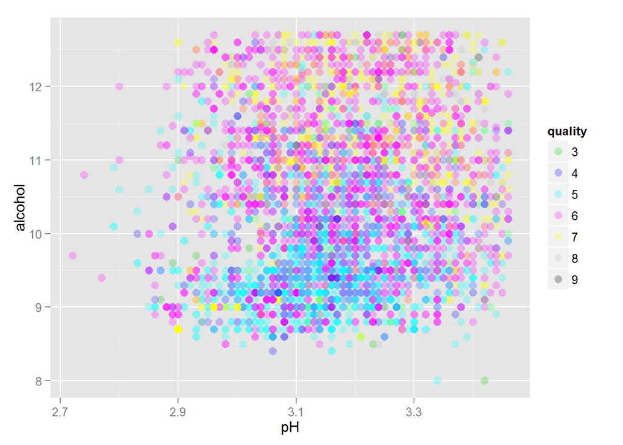

```r
ggplot(aes(x = pH, y = alcohol, color = quality), data = whitewine) +
    geom_point(size = 3, alpha = 1/4) +
    scale_color_identity(guide = 'legend') +
    ylim(min(whitewine$alcohol), quantile(whitewine$alcohol, 0.95)) +
    xlim(min(whitewine$pH), quantile(whitewine$pH, 0.95))
```

Citric Acid and Alcohol

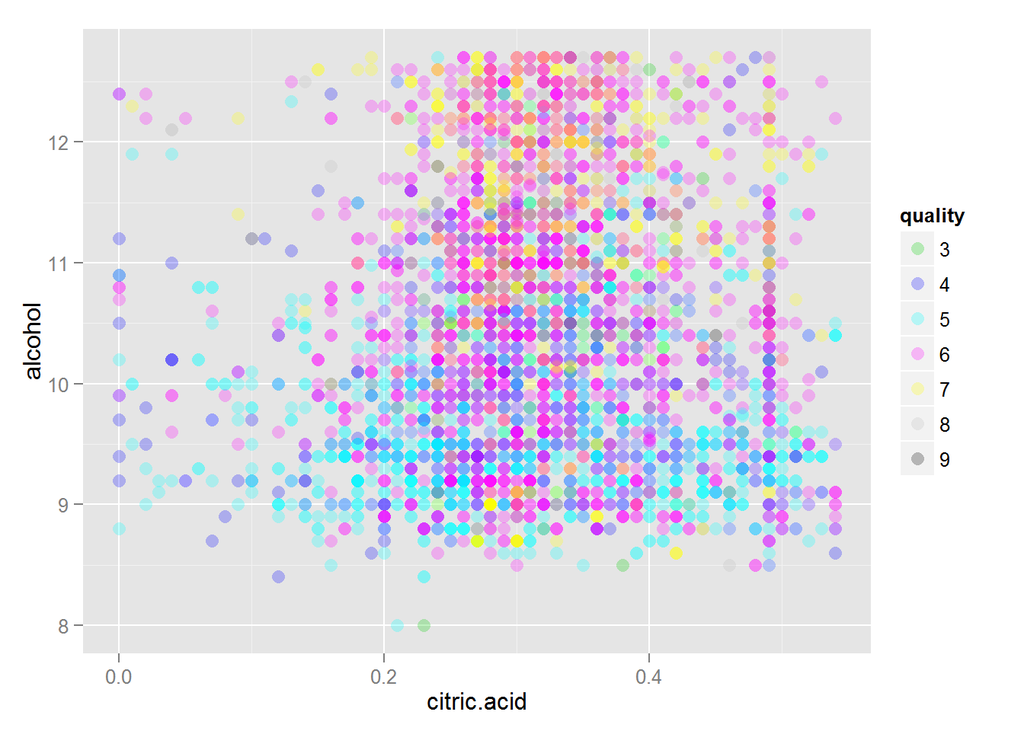

```r
ggplot(aes(x = citric.acid, y = alcohol, color = quality),
       data = whitewine) +
    geom_point(size = 3, alpha = 1/4) +
    scale_color_identity(guide = 'legend') +
    ylim(min(whitewine$alcohol), quantile(whitewine$alcohol, 0.95)) +
    xlim(min(whitewine$citric.acid), quantile(whitewine$citric.acid, 0.95))
```

we can notice that most of the wine is clustered around where citric acid is 0.2 - 0.4.

## Final Plots and Summary

Plot One: Quality of Wine

`r ggplot(data = whitewine, aes(x = density, y = alcohol, color = factor(quality))) + geom_point(alpha = 1/2, position = position_jitter(h = 0), size = 2) + coord_cartesian(xlim=c(min(whitewine$density),1.005), ylim=c(8,15)) + scale_color_brewer(type='qual') + xlab('Density') + ylab('Alcohol') + ggtitle('Density vs. Alcohol correlation by Quality')`

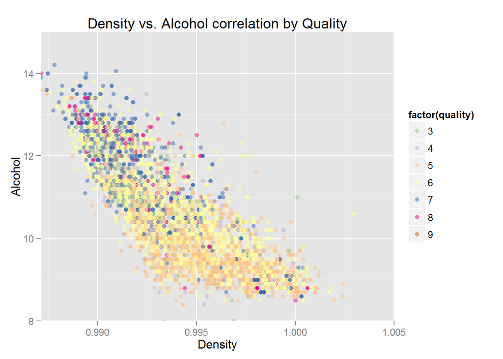

`r ggplot(data = whitewine, aes(x = density, y = alcohol) )+ facet_wrap( ~ quality) + geom_boxplot() + xlab('Density') + ylab('Alcohol') + ggtitle('Density vs. Alcohol correlation by Quality')`

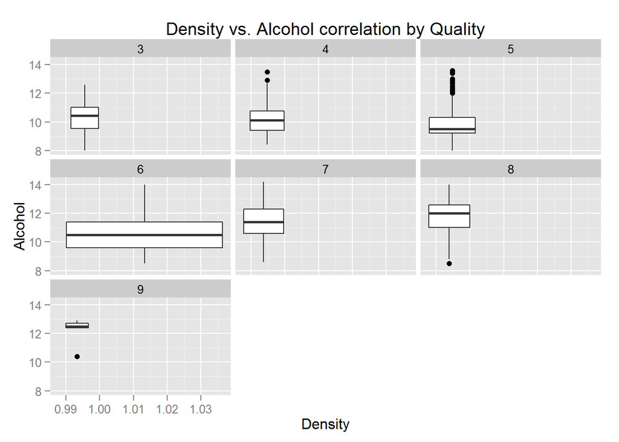

Plot Three: Quality vs. Alcohol

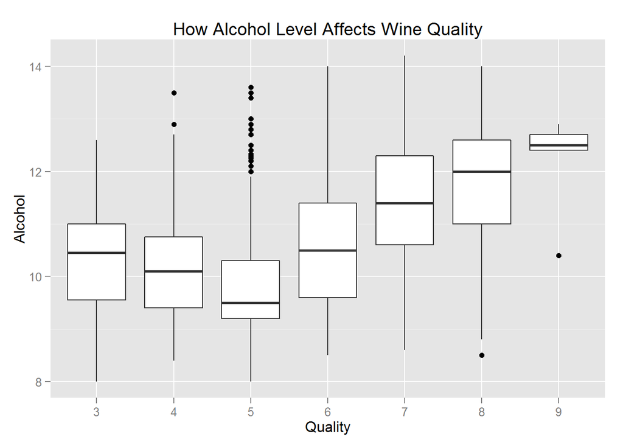

```r
ggplot(data = whitewine, aes(y = alcohol, x = quality)) +
   geom_boxplot() +
   geom_smooth(method = 'lm') +
   xlab('Quality') +
   ylab('Alcohol') +
   ggtitle('How Alcohol Level Affects Wine Quality')
```

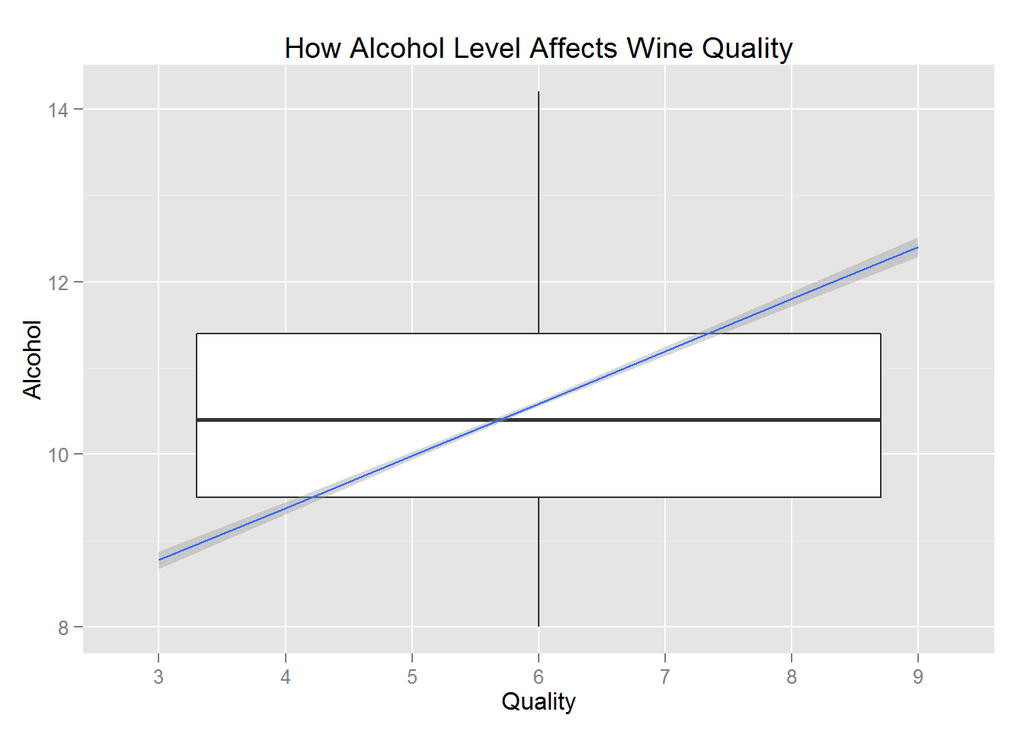

```r
ggplot(data = whitewine, aes(y = alcohol, x = quality,group = 1)) +
   geom_boxplot() +
   geom_smooth(method = 'lm') +
   xlab('Quality') +
   ylab('Alcohol') +
   ggtitle('How Alcohol Level Affects Wine Quality')
```

Description

Alcohol level and Quality have correlation value of 0.4. This is the strongest correlation we have found between an objective wine parameter and wine quality. 0.4 is not a high correlation level so we cannot use alcohol as a parameter for quality prediction.

## Reflection

i took white wine data from the suggested data with multiple reasons in mind to choose this data set. i never had a alcohol, never tested as well but through this exercise i want to challenge my self if i can work on something where i have no experience.

After analyzing the data i concluded the below items :

For future exploration of this data I would pick one category of wine (for example, quality level 3-4, 5-7, 8-9) to look at the patterns which can appear in each of these three buckets.